# Weekly Assignment 1

Alex Takoudes

2023-01-12

## Getting Started with Git and Rstudio

##### This guide is designed for users with macOS Ventura 13.1 or newer

### 1. Downloading Xcode

1. Download the full version of Xcode from the [Apple App Store](https://apps.apple.com/us/app/xcode/id497799835?mt=12)
2. Open the application and accept any terms and conditions

### 2. Downloading Homebrew

1. Search for `Terminal` in your mac spotlight search and open it

[figure not shown]

2. Go to [Homebrew](https://brew.sh) and copy the first line of code

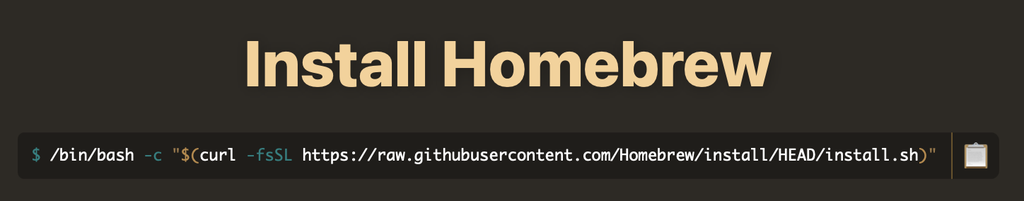

3. You might need to type in your computer password to authorize the download
4. If Terminal returns any authentication errors, type `git config --global http.sslVerify false` to temporarily disable any filters
- **Make sure to type `git config --global http.sslVerify true` after Homebrew is finished installing**
5. Homebrew might prompt you to copy three lines of code. Simply copy them and paste into terminal and hit enter
6. Once the download is finished type `brew install git`
7. Restart Rstudio if it was open

### 3. Setting up Github Token

1. Go to [Github](https://github.com) and sign in
2. Click your profile icon on the upper right corner (next to bell and + signs)
3. Go to Settings
4. On the left side of the screen, scroll all the way down and choose Developer settings
5. On the left, click Personal access tokens and choose Tokens (classic)
6. Click Generate new token and choose the Classic option
7. Write “BIOL1007A” for the Note
8. Under Expiration, choose Custom - and set the expiration date to 12/31/2023
9. Click the repo check box (first one under select scopes) and it will select all of the sub boxes
10. Scroll down and select Generate token
11. **Copy the entire token number it generates** and save it somewhere - either in a document or note or email it to yourself

### 4. Setting up a Repository

1. On your Github home page, create a new repository by clicking the “new” button
2. Name it `BIOL1007A`
3. Check the box to include a ReadMe statement
4. Add a MIT License
5. Click `Create Repository`

### 5. Cloning your Repository

1. Open Rstudio (if it was already open, restart it)
2. In the top right, open the drop down menu and select `New Project`
3. Select `Version Control`
4. Select `Git`
- Rstudio needs the URL to your Github Repository
- Go to Github
- Open your ‘BIOL1007A’ Repository
- Click the green `<> Code` button
- Make sure `HTTPS` is selected and copy the URL
5. Paste the repository URL into Rstudio
6. Name the project `BIOL1007A` or the exact name you gave it on Github
7. Use the browse button to put it somewhere on your computer and click `Create Project`

### Navigating your project

1. On the right side, you should see your license and ReadMe files have populated the files tab.
- You can open your existing documents from here
2. You can create a new file by clicking the plus in the top left and selecting `RMarkdown`
3. Name the file `index`
4. This will automatically populate with default text so delete everything except for the header (A.K.A. YAML)
5. Type anything into the body of the document and click save
6. Name the file `index` when you save it

### Uploading to your Github Repository

1. Where your console is currently open, click on Terminal
2. In Terminal type `git status`
- This will show you what unsaved changes you have
3. Type `git add -A` to add all changes
4. Type `git commit -am "<description of changes>"`
5. Type `git push`
- This will prompt you for your Github username
- If it asks for the password, put the access token we generated earlier
- Once complete, if there are any errors do these 4 steps
- In Console, run `install.packages("credentials")`
- In Terminal, run `git config --global user.email "put github email here"`
- In Terminal, run `git config --global user.name "put your name here"`
- In Console, run `credentials::set_github_pat("put PAT here")`
6. This should push all your changes to Github and you should be able to see them on github.com

### Creating a Webpage from Repository

1. Go to your repository on Github
2. Go to `Settings`
3. On the left side, select `Pages`
4. Scroll down and under `Branch` change from `None` to `main`
5. Wait 2 minutes, refresh the page, and a link to your webpage will appear at the top